# rna-seq-survey-MS-v2020 12 24

# Generate schematic defining read types

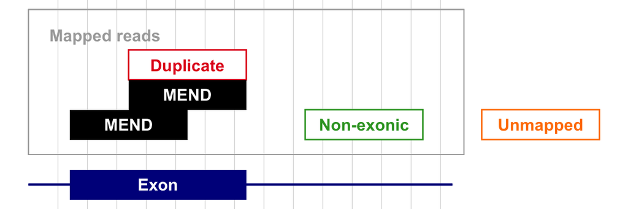

```r
colors_for_read_types <- these_colors_with_MEND
names(colors_for_read_types) <- gsub(" reads", "", names(these_colors_with_MEND))

colors_for_read_types <- c(colors_for_read_types,
                           "Genome" = "darkblue",
                           "Exon" = "darkblue",
                           "Mapped reads" = "darkgrey")

plot1_colnames <- c("label", "x1", "x2", "y1", "y2")

read_type_schematic_data_as_vector <- c("Duplicate", 3, 4, 5, 6,
                       "MEND", 3, 4, 4, 5,
                       "MEND", 2.5, 3.5, 3, 4,
                       "Non-exonic", 4.5, 5.5, 3, 4,
                       "Unmapped", 6, 7, 3, 4,
                       "Exon", 2.5, 4, 1, 2,
                       "Mapped reads", 2.8, 2.8, 6, 7)

rows_in_schematic <- length(read_type_schematic_data_as_vector)/length(plot1_colnames)

read_type_schematic_data <- matrix(read_type_schematic_data_as_vector,
                     ncol = length(plot1_colnames), byrow = TRUE,
                     dimnames = list(c(1:rows_in_schematic), plot1_colnames)) %>%
  as_tibble %>%
  type_convert() %>%
  mutate(
    base_color = colors_for_read_types[match(label, names(colors_for_read_types))],
    border_color = case_when(
      label %in% c("Mapped reads", "Genome", "MEND", "Exon") ~ NA_character_,
      TRUE ~ base_color),
    fill_color = ifelse(label %in% c("MEND", "Exon"),  base_color, "white"),
    text_color = case_when(
      label %in% c("MEND", "Exon")~  "white",
      TRUE ~ base_color),
    mid_bar_x = map2_dbl(x1, x2,  function(x, y) mean(c(x,y))),
    mid_bar_y = map2_dbl(y1, y2,  function(x, y) mean(c(x,y)))
  )
padding_size = 0.35
end_of_box <- sort(read_type_schematic_data$x2,partial=length(read_type_schematic_data$x2)-1)[length(read_type_schematic_data$x2)-1] + padding_size
read_type_schematic <- ggplot(read_type_schematic_data,
                              aes(xmin=x1, xmax=x2, ymin=y1, ymax = y2,
                                  fill = fill_color, color = border_color)) +
  geom_rect() +

  geom_segment(x=min(read_type_schematic_data$x1-padding_size), y=1.5, xend = 5.75, yend = 1.5, color = "darkblue") +
  geom_text(aes(label = label, x = mid_bar_x, y=mid_bar_y,
                color = text_color),
            size = 4,
            fontface = "bold") +
  geom_rect(aes(xmin = min(x1 - padding_size),
                ymin = 2.5,
                xmax = end_of_box,
                ymax=max(y2 + padding_size)),
            fill = NA, color = "darkgrey", size = 0.25) +
  scale_fill_identity() +
  scale_color_identity() +
  theme_void() +
  theme(
    panel.grid.major.x = element_line(color="lightgrey", size=0.2),
    ) +
 scale_x_continuous(
   breaks = seq(min(read_type_schematic_data$x1) - padding_size + 0.25, end_of_box , 0.25))

read_type_schematic
```

# Generate schematic defining read type fractions

```r
stat_names <- c("pct_unmapped_of_total",  "pct_dupe_of_mapped", "pct_non_exonic_of_non_dupe")
stat_labels <- c("Unmapped",  "Duplicate", "Non-exonic")
complement_stat_names <- c("Mapped reads",  "Non-duplicate reads", "Exonic reads")
divisor_name = c("total", "mapped", "non-duplicate")

comparison_of_remaining <- read_type_fractions_long %>%
  mutate(read_type_fraction_name = complement_stat_names[match(read_type_fraction_name, stat_names)]) %>%
  group_by(read_type_fraction_name) %>%
  summarize(min = round(1-max(dataset_value), 2),
    max = round(1-min(dataset_value), 2),
    median = round(1-median(dataset_value), 2),
    p25 = round(1-quantile(dataset_value, 0.25), 2),
    p75 = round(1-quantile(dataset_value, 0.75), 2)) %>%
#      mutate(bar_label = paste0 (read_type_fraction_name, "\n(", 100*min, "-", 100*max, "% of ", divisor_name[match(read_type_fraction_name, complement_stat_names)], "; x͂=",100* median, "%)"))
mutate(bar_label = paste0 (read_type_fraction_name, "\n(", 100*min, "-", 100*max, "% of ", divisor_name[match(read_type_fraction_name, complement_stat_names)], "; med.=", 100* median, "%)"))
positive_bars <- comparison_of_remaining %>%
  select(-min, -max, -p25, -p75) %>%
  mutate(read_type_fraction_label = read_type_fraction_name,
         position = "1") %>%
  rename(abs_median = median)

negative_bars <- tibble(read_type_fraction_name = positive_bars$read_type_fraction_name,
                        read_type_fraction_label = stat_labels[match(read_type_fraction_name, complement_stat_names)],
                        bar_label = read_type_fraction_label,
                        abs_median = 1-positive_bars$abs_median,
                        position = "2")

total_bar <- tibble(read_type_fraction_name = "Total reads",
                    read_type_fraction_label = read_type_fraction_name,
                    bar_label = "Total reads\n(100% of reads)",
                    abs_median = 1,
                    position = "1"
                    )


MEND_stats_of_total <- counts_and_meta  %>%
  arrange(desc(Total_reads)) %>%
  mutate(
    pct_MEND_of_total = (Total_reads - MEND) / Total_reads
  ) %>%
  ungroup %>%
  summarize(min = round(1-max(pct_MEND_of_total), 2),
    max = round(1-min(pct_MEND_of_total), 2),
    median = round(1-median(pct_MEND_of_total), 2))

MEND_bar <- tibble(read_type_fraction_name = "MEND reads",
                   read_type_fraction_label = read_type_fraction_name,
                   bar_label = with(MEND_stats_of_total, paste0 ("MEND reads\n(", 100*min, "-", 100*max, "% of total reads; med.=",100* median, "%)")),
                   abs_median = 1,
                   position = "1"
)

bar_names_in_order <- c("Total reads", "Mapped reads", "Non-duplicate reads", "Exonic reads", "MEND reads")

all_bars <- bind_rows(positive_bars, negative_bars, total_bar, MEND_bar) %>%
  mutate(read_type_fraction_name = factor(read_type_fraction_name,
                                          levels = bar_names_in_order))

cat_space <- all_bars %>% filter(position == 1) %>%
  arrange(read_type_fraction_name) %>%
  select(read_type_fraction_name, abs_median) %>%
  ungroup %>%
  mutate(lagged1_abs_median = lag(abs_median, default =1),
         lagged2_abs_median = lag(abs_median, n=2, default =1),
         category_space = lagged1_abs_median*lagged2_abs_median
         ) %>%
  select(read_type_fraction_name, category_space)

these_colors_with_MEND = c(these_colors, "MEND reads"="#000000")


all_bars_rel <- left_join(all_bars, cat_space, by = "read_type_fraction_name") %>%
  mutate(rel_median=ifelse(read_type_fraction_name == "MEND reads",
                           abs_median[read_type_fraction_label=="Exonic reads"]*
                             category_space[read_type_fraction_label=="Exonic reads"],
                           abs_median*category_space),
         read_type_fraction_name = factor(read_type_fraction_name, levels = rev(bar_names_in_order)),
         position = factor(position, levels = rev(sort(unique(position)))),
         bar_color = these_colors_with_MEND[match(read_type_fraction_name, names(these_colors_with_MEND))],
         fill_val = ifelse(position == 1, bar_color, NA),
         border_color_val = bar_color,
         text_color = ifelse(position ==1, "white", "black"),
font_size = ifelse(abs_median<0.1, 3,3.5),
text_angle = ifelse(abs_median<0.1, 90,0)
         )
```

# read_type_fractions_schematic

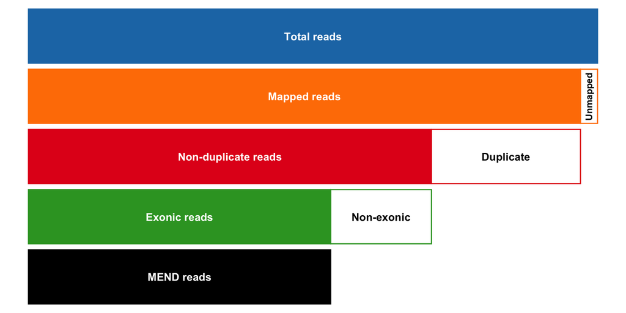

```r
read_type_fractions_schematic <- ggplot(all_bars_rel, aes(y=read_type_fraction_name,
                x=rel_median, group = position)) +
   geom_col(aes(fill = fill_val,
                color = border_color_val
                )) +
   geom_text(aes(label=bar_label,
                 color = text_color,
                 size = font_size,
                 angle= text_angle),
             position = position_stack(vjust = .5),
              fontface = "bold") +
   scale_fill_identity() +
   scale_color_identity()  +
  scale_size_identity() +
   theme_void() +
  theme(axis.title.y=element_blank(),
        axis.text.y=element_blank(),
        axis.ticks.y=element_blank())


ggplot(all_bars_rel, aes(y=read_type_fraction_name,
                x=rel_median, group = position)) +
   geom_col(aes(fill = fill_val,
                color = border_color_val
                )) +
   geom_text(aes(label=read_type_fraction_label,
                 color = text_color,
                 size = font_size,
                 angle = text_angle),
             position = position_stack(vjust = .5),
              fontface = "bold") +
   scale_fill_identity() +
   scale_color_identity()  +
  scale_size_identity() +
   theme_void() +
  theme(axis.title.y=element_blank(),
        axis.text.y=element_blank(),
        axis.ticks.y=element_blank())
```

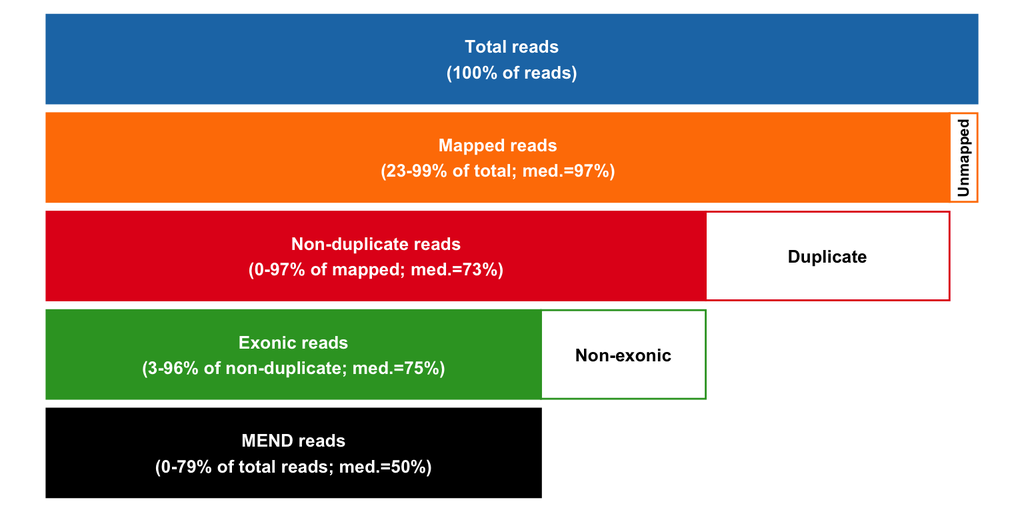

```r
read_type_fractions_schematic
```

# Figure 2

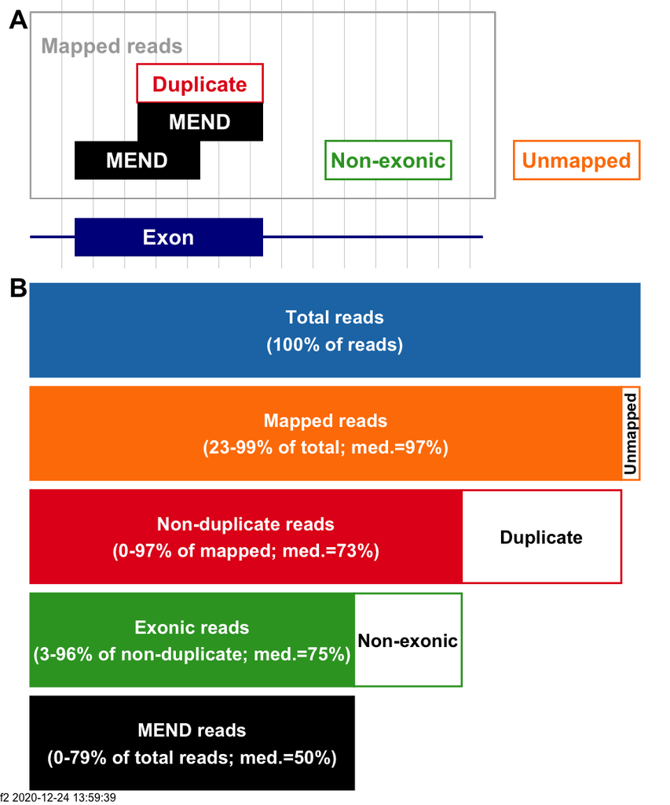

```r
figure_name <- "f2"

f2 <- plot_grid(read_type_schematic,
read_type_fractions_schematic,
nrow=2,
rel_heights = c(1, 2),
labels = c("A", "B")) +
   draw_label(paste(figure_name, Sys.time()),
              x = 0, y = 0.01, hjust = 0, size = 6)
#
# f2 <- plot_grid(left_side,
# right_side,
# ncol = 2) +
#    draw_label(paste(figure_name, Sys.time()),
#               x = 0, y = 0.02, hjust = 0, size = 6)

f2
```

```r
ggsave("results/Figure_2.png", f2, height=6, width=5)
ggsave("results/Figure_2.pdf", f2, height=6, width=5)
```

```r
stat_names <- c("pct_unmapped_of_total",  "pct_dupe_of_mapped", "pct_non_exonic_of_non_dupe")
stat_label <- c("% unmapped", "% duplicate \n(of mapped)", "% non-exonic \n(of non-duplicate)")
names(stat_label) <- stat_names
```

# Plot read fractions

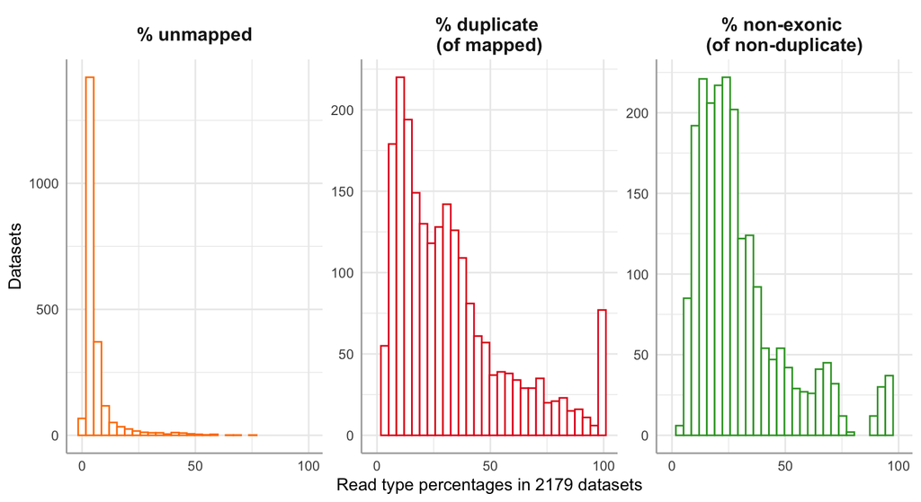

```r
colors_for_stat_names <- these_colors[c("Mapped reads", "Non-duplicate reads","Exonic reads")]
names(colors_for_stat_names) <- stat_names

these_colors <- c("#A6CEE3", "#1F78B4", "#B2DF8A", "#33A02C", "#FB9A99", "#E31A1C",
"#FDBF6F", "#FF7F00")
# light blue, dark blue, etc: green, red, orange (then purple and brown)
names(these_colors) <-  c("not assigned", "Total reads", "Non-exonic reads",  "Exonic reads", "Duplicate reads",  "Non-duplicate reads",  "Unmapped reads", "Mapped reads")

# 6 x 11 was a good ratio, but the text was too small

read_type_fractions_long_for_histogram <- read_type_fractions_long %>%
  mutate(read_type_fraction_name = factor(read_type_fraction_name,
                                          levels = stat_names))

read_type_fractions_histogram <-  ggplot(read_type_fractions_long_for_histogram) +
  geom_histogram(aes(x = dataset_value*100, color = read_type_fraction_name),
                 fill = "white", stat = StatBin2)  +
  scale_color_manual(values = colors_for_stat_names) +
  facet_wrap(~read_type_fraction_name,
             nrow = 1,
             scales = "free_y",
             labeller = labeller(
               read_type_fraction_name = stat_label
             )
  ) +
  ylab("Datasets") +
  xlab(paste0("Read type percentages in ", length(unique(read_type_fractions_long_for_histogram$dataset_id)),  " datasets")) +
#  scale_x_continuous(breaks = seq(0, 1, by = 0.5)) +
    scale_x_continuous(breaks = seq(0, 100, by = 50)) +
  theme_minimal() +
  theme(axis.line.x = element_line(color="darkgrey", size = 0.5),
        axis.line.y = element_line(color="darkgrey", size = 0.5)) +
  theme(strip.text.x = element_text(size = 12, face = "bold")) +
  theme(legend.position = "none")

read_type_fractions_histogram
```

# Calculate MEND reads as a fraction of total

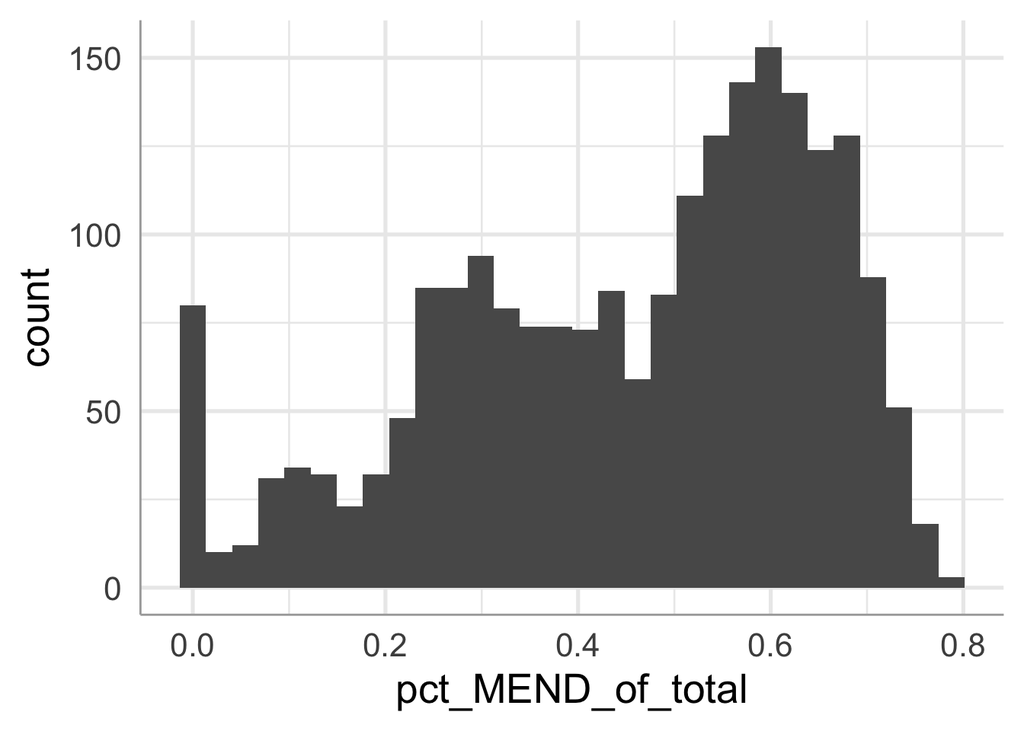

```r
read_counts_with_MEND_fractions <- counts_and_meta  %>%
  arrange(desc(Total_reads)) %>%
  mutate(pct_MEND_of_total = MEND /Total_reads)

ggplot(read_counts_with_MEND_fractions) +
  geom_histogram(aes(pct_MEND_of_total), stat = StatBin2) +
    theme_minimal(base_size = 20) +
    theme(axis.line.x = element_line(color="darkgrey", size = 0.5),
        axis.line.y = element_line(color="darkgrey", size = 0.5))
```

```r
MEND_pct <- read_counts_with_MEND_fractions %>%
  ungroup %>%
  mutate(dataset_value = pct_MEND_of_total) %>%
  summarize(variance= var(dataset_value),
            min = min(dataset_value),
            max = max(dataset_value),
            median = median(dataset_value),
            p25 = quantile(dataset_value, 0.25),
            p75 = quantile(dataset_value, 0.75),
            iqr = IQR(dataset_value))

kable(MEND_pct %>%
        select(-variance, -p25, -p75) %>%
      mutate_if(is.double, ~100*.), digits = 0) %>%
  kable_styling(bootstrap_options = "striped", full_width = F)
```

| min | max | median | iqr |
| --- | --- | --- | --- |
| 0 | 79 | 50 | 31 |

```r
head(sort(read_counts_with_MEND_fractions$pct_MEND_of_total))
```

```
## [1] 0.0000267009 0.0002533711 0.0003651723 0.0003767257 0.0003997294
## [6] 0.0004279584
```

```r
sum(read_counts_with_MEND_fractions$pct_MEND_of_total<0.25)
```

```
## [1] 355
```

```r
read_counts_with_MEND_fractions %>%
  ungroup %>%
  mutate(pct_under_25 = pct_MEND_of_total<0.25) %>%
  tabyl(pct_under_25) %>%
  adorn_totals()
```

```
##  pct_under_25    n   percent
##         FALSE 1824 0.8370812
##          TRUE  355 0.1629188
##         Total 2179 1.0000000
```

```r
read_counts_with_MEND_fractions %>%
  ungroup %>%
  filter(Mapped > 30E6) %>%
  mutate(pct_under_25 = pct_MEND_of_total<0.25) %>%
  tabyl(pct_under_25) %>%
  adorn_totals()
```

```
##  pct_under_25    n   percent
##         FALSE 1739 0.8368624
##          TRUE  339 0.1631376
##         Total 2078 1.0000000
```

# Show per-cohort distribution of read_type_fractions

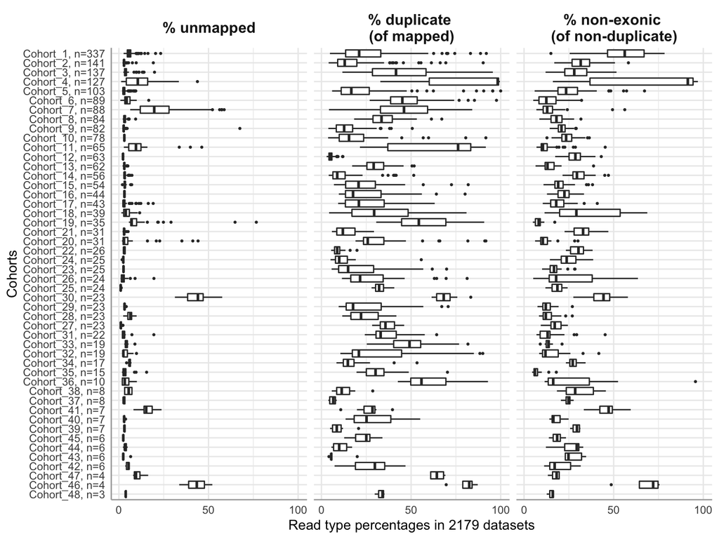

```r
figure_name <- "fracs_by_group"

read_type_fractions_long_for_boxplot <- read_type_fractions_long_for_histogram %>%
  ungroup %>%
  mutate(boxplot_label = fct_reorder(paste0(as.character(cohort_code), ", n=", n_in_cohort), n_in_cohort))


read_type_fractions_per_cohort_boxplot <- ggplot(read_type_fractions_long_for_boxplot) +
  geom_boxplot(aes(x = dataset_value*100, y=boxplot_label), outlier.size = 0.5)  +
  facet_wrap(~read_type_fraction_name,
             nrow = 1,
             labeller = labeller(
               read_type_fraction_name = stat_label
             )
  ) +
  ylab("Cohorts") +
  xlab(paste0("Read type percentages in ", length(unique(read_type_fractions_long_for_boxplot$dataset_id)),  " datasets")) +
  #  scale_x_continuous(breaks = seq(0, 1, by = 0.5)) +
  scale_x_continuous(breaks = seq(0, 100, by = 50)) +

  theme_minimal() +
  theme(axis.line.x = element_line(color="darkgrey", size = 0.5),
        axis.line.y = element_line(color="darkgrey", size = 0.5)) +
  theme(strip.text.x = element_text(size = 12, face = "bold")) +
  theme(legend.position = "none")


read_type_fractions_per_cohort_boxplot
```

# Characterize Cohort 4

```r
read_type_names <- c("Total_reads", "Mapped",  "MND", "MEND")
```

```r
this_cohort_name <- "EGAD00001003279"

this_cohort_code <- subset(read_counts_with_read_type_fractions, cohort_name == this_cohort_name)$cohort_code[1]

this_cohort_code
```

```
## [1] "Cohort_4"
```

## in MS

```r
 read_counts_with_read_type_fractions %>%
  filter(cohort_code == this_cohort_code) %>%
   mutate(gt_98 = pct_dupe_of_mapped > 0.98) %>%
   tabyl(gt_98) %>%
   # add_totals_row
  adorn_totals("row")
```

```
##  gt_98   n   percent
##  FALSE  55 0.4330709
##   TRUE  72 0.5669291
##  Total 127 1.0000000
```

```r
 read_counts_with_read_type_fractions %>%
  filter(cohort_code == this_cohort_code) %>%
  filter(pct_dupe_of_mapped > 0.98) %>%
  pull(Total_reads) %>% min
```

```
## [1] 178294341
```

```r
 read_counts_with_read_type_fractions %>%
  filter(cohort_code == this_cohort_code) %>%
  filter(pct_dupe_of_mapped > 0.98) %>%
   pull(genes_with_at_least_1_count) %>% max
```

```
## [1] 39
```

## other

```r
 counts_and_meta_long <- counts_and_meta  %>%
  pivot_longer(cols = c(Total_reads, Mapped, MEND, MND), names_to = "read_type_name", values_to = "dataset_value")  %>%
   ungroup %>%
   mutate(read_type_name = factor(read_type_name, levels = read_type_names))

counts_and_meta_long_one_proj <-  counts_and_meta_long %>%
  filter(cohort_code == this_cohort_code)

table(counts_and_meta_long_one_proj$read_type_name)
```

```
##
## Total_reads      Mapped         MND        MEND
##         127         127         127         127
```

```r
# 78 datasets in the cohort have fewer than 0.2 million MEND reads.
sum((counts_and_meta_long_one_proj %>% filter(read_type_name=="MEND"))$dataset_value < 200000)
```

```
## [1] 78
```

```r
those_datasets <- counts_and_meta_long_one_proj %>% filter(read_type_name=="MEND", dataset_value < 200000) %>% pull(dataset_id)


summary((counts_and_meta_long_one_proj %>% filter(read_type_name=="Total_reads", dataset_id %in% those_datasets))$dataset_value)
```

```
##      Min.   1st Qu.    Median      Mean   3rd Qu.      Max.
## 178294341 199916664 208667776 211606891 223832191 247618832
```

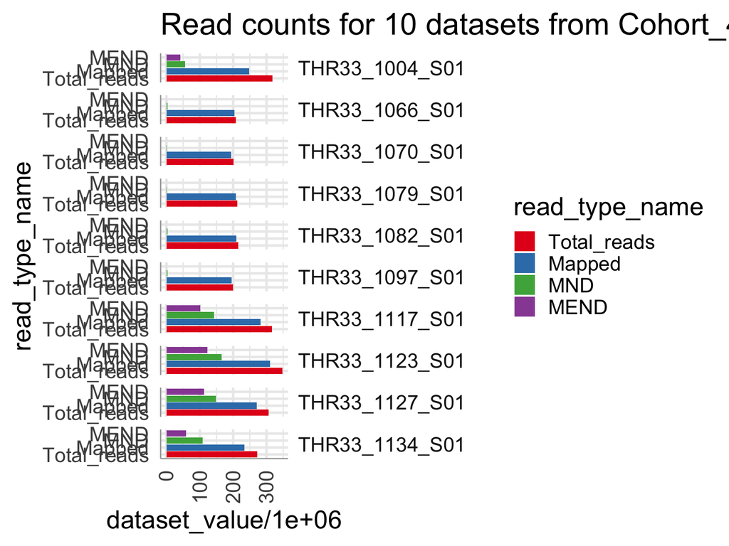

```r
max_plots_to_include <- 10
n_datasets_to_plot <- ifelse(n_distinct(counts_and_meta_long_one_proj$dataset_id)>max_plots_to_include,
                         max_plots_to_include,
                         n_distinct(counts_and_meta_long_one_proj$dataset_id))
plot_word <- ifelse(n_datasets_to_plot==max_plots_to_include, max_plots_to_include, paste("all", n_distinct(counts_and_meta_long_one_proj$dataset_id)))

set.seed(100)
datasets_to_plot <- sample(unique(counts_and_meta_long_one_proj$dataset_id), n_datasets_to_plot)

ggplot(subset(counts_and_meta_long_one_proj, dataset_id %in% datasets_to_plot)) +
  geom_col(aes(x=read_type_name, y=dataset_value/1e6, fill = read_type_name)) +
  facet_wrap(~dataset_id, ncol = 1, strip.position="right")  +
    theme_minimal(base_size = 20) +
    theme(axis.line.x = element_line(color="darkgrey", size = 0.5),
        axis.line.y = element_line(color="darkgrey", size = 0.5)) +
  theme(strip.text.y = element_text(angle = 0)) +
  scale_fill_brewer(palette = "Set1")  +
  theme(axis.text.x = element_text(angle = 90, hjust = 1, vjust = 0.5)) +
  ggtitle(paste("Read counts for", plot_word, "datasets from", this_cohort_code)) +
  coord_flip()
```

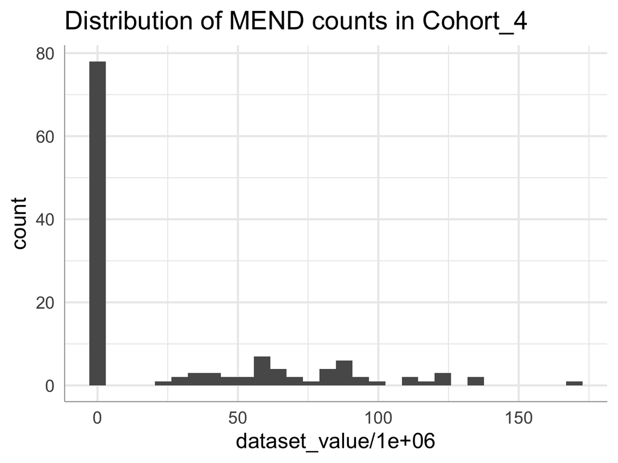

```r
ggplot(counts_and_meta_long_one_proj %>% filter(read_type_name == "MEND")) +
  geom_histogram(aes(dataset_value/1e6), stat = StatBin2) +
    theme_minimal(base_size = 20) +
    theme(axis.line.x = element_line(color="darkgrey", size = 0.5),
        axis.line.y = element_line(color="darkgrey", size = 0.5)) +
  ggtitle(paste("Distribution of MEND counts in", this_cohort_code))
```

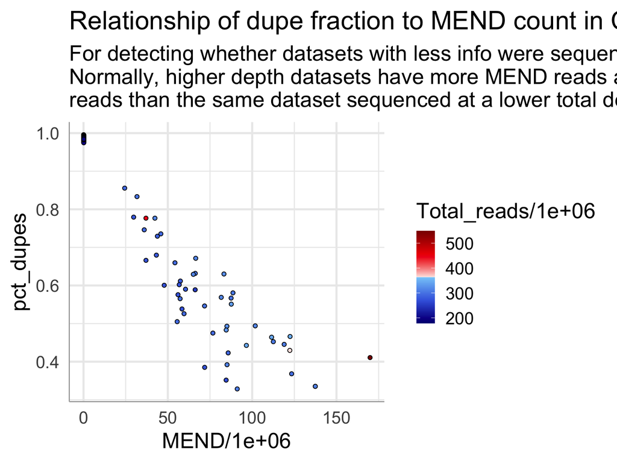

```r
bl <- colorRampPalette(c("navy","royalblue","lightskyblue"))(200)
re <- colorRampPalette(c("mistyrose", "red2","darkred"))(200)


ggplot(counts_and_meta %>%
         filter(cohort_code == this_cohort_code) %>%
         mutate(pct_dupes = (Mapped - MND)/Mapped)) +
  geom_point(aes(x=MEND/1e6, y=pct_dupes, fill = Total_reads/1e6), shape=21, color = "black") +
    theme_minimal(base_size = 20) +
    theme(axis.line.x = element_line(color="darkgrey", size = 0.5),
        axis.line.y = element_line(color="darkgrey", size = 0.5)) +
  scale_fill_gradientn(colours = c(bl,"white", re)) +
  ggtitle(paste("Relationship of dupe fraction to MEND count in", this_cohort_code), "For detecting whether datasets with less info were sequenced more deeply. \nNormally, higher depth datasets have more MEND reads and more duplicate \nreads than the same dataset sequenced at a lower total depth.")
```

```r
counts_and_meta_long_one_proj %>%
  select(seq_length, dataset_id) %>%
  distinct %>%
  tabyl(seq_length)
```

```
##  seq_length   n percent
##          51 127       1
```

```r
# what dataset outside this project has the highest fraction of duplicate reads

 read_counts_with_read_type_fractions %>%
  filter(cohort_code != this_cohort_code) %>%
  arrange(desc(pct_dupe_of_mapped))
```

```
## # A tibble: 2,052 x 25
## # Groups:   cohort_code [47]
##    dataset_id Total_reads Mapped    MND   MEND seq_length disease age_at_dx
##    <chr>            <dbl>  <dbl>  <dbl>  <dbl>      <dbl> <chr>       <dbl>
##  1 THR24_146…   130543363 1.25e8 4.21e3 3.49e3        101 acute …      2.41
##  2 THR31_090…    98380162 9.15e7 2.14e6 1.90e6        110 hypere…     NA
##  3 TARGET-20…   456285836 3.66e8 1.60e7 1.03e7         75 acute …     12.6
##  4 THR24_151…    81018320 7.93e7 3.52e6 2.15e6        101 acute …     NA
##  5 THR24_155…   136554857 1.27e8 5.65e6 2.92e6        101 acute …     NA
##  6 THR25_064…   166970701 1.58e8 1.12e7 5.32e6         75 not re…     17
##  7 TARGET-20…   168759996 1.45e8 1.12e7 9.24e6         75 acute …     13.5
##  8 TARGET-20…   250106942 2.17e8 1.73e7 1.43e7         75 acute …     14.2
##  9 TARGET-10…   210825420 1.94e8 1.56e7 1.32e7         75 acute …      3.01
## 10 THR14_032…   102631146 5.73e7 4.74e6 3.31e6        100 glioma       9.8
## # … with 2,042 more rows, and 17 more variables: pedaya <chr>,
## #   gender <chr>, race <chr>, ethnicity <chr>, cohort_code <chr>,
## #   cohort_name <chr>, doi_link <chr>, source_repository <chr>,
## #   repository_cohort_accession <chr>, repository_dataset_accession <chr>,
## #   genes_with_at_least_1_count <dbl>, duration_of_expression <dbl>,
## #   duration_of_mend <dbl>, n_in_cohort <int>,
## #   pct_unmapped_of_total <dbl>, pct_dupe_of_mapped <dbl>,
## #   pct_non_exonic_of_non_dupe <dbl>
```

```r
# samples with greater than 90% duplicates
 read_counts_with_read_type_fractions %>%
  filter(cohort_code != this_cohort_code) %>%
   filter(pct_dupe_of_mapped > 0.9) %>%
   select(dataset_id, n_in_cohort, Total_reads, pct_dupe_of_mapped, genes_with_at_least_1_count) %>%
  arrange(desc(pct_dupe_of_mapped))
```

```
## # A tibble: 20 x 6
## # Groups:   cohort_code [11]
##    cohort_code dataset_id n_in_cohort Total_reads pct_dupe_of_map…
##    <chr>       <chr>            <int>       <dbl>            <dbl>
##  1 Cohort_5    THR24_146…         103   130543363            1.00
##  2 Cohort_6    THR31_090…          89    98380162            0.977
##  3 Cohort_3    TARGET-20…         137   456285836            0.956
##  4 Cohort_5    THR24_151…         103    81018320            0.956
##  5 Cohort_5    THR24_155…         103   136554857            0.956
##  6 Cohort_36   THR25_064…          10   166970701            0.929
##  7 Cohort_3    TARGET-20…         137   168759996            0.923
##  8 Cohort_3    TARGET-20…         137   250106942            0.920
##  9 Cohort_1    TARGET-10…         337   210825420            0.920
## 10 Cohort_20   THR14_032…          31   102631146            0.917
## 11 Cohort_10   THR24_181…          78    76022345            0.917
## 12 Cohort_11   TARGET-52…          65   257224716            0.917
## 13 Cohort_3    TARGET-20…         137   259704362            0.915
## 14 Cohort_20   THR14_032…          31    78952869            0.911
## 15 Cohort_11   TARGET-52…          65   231487526            0.911
## 16 Cohort_19   THR15_033…          35   117836240            0.908
## 17 Cohort_5    THR24_154…         103    71034608            0.905
## 18 Cohort_2    THR24_168…         141   110517793            0.902
## 19 Cohort_11   TARGET-52…          65   193433236            0.902
## 20 Cohort_32   THR10_023…          19    47417884            0.900
## # … with 1 more variable: genes_with_at_least_1_count <dbl>
```

```r
 summary(read_counts_with_read_type_fractions$genes_with_at_least_1_count)
```

```
##    Min. 1st Qu.  Median    Mean 3rd Qu.    Max.
##       8   26048   27980   27231   29916   44808
```

# Expressed genes

## What is the distribution of measured genes?

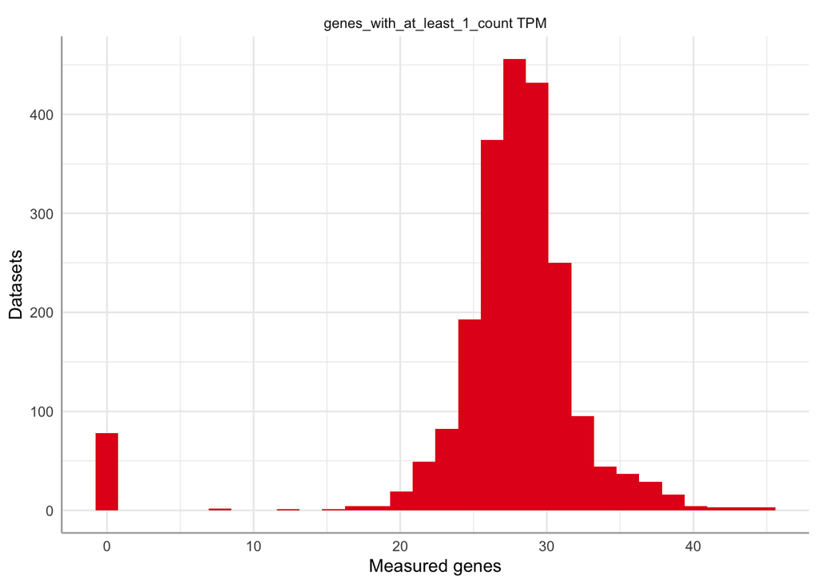

```r
gene_counts_long <- counts_and_meta %>%
  pivot_longer(cols = starts_with("genes_"), names_to = "Expression_threshold")  %>%
  mutate(Expression_threshold = paste(str_replace(Expression_threshold, "genes_expressed_above_", "genes > "), "TPM"))


ggplot(gene_counts_long) +
  geom_histogram(aes(x=value/1e3, fill = Expression_threshold), stat = StatBin) +
  facet_wrap(~Expression_threshold)  +
    theme_minimal() +
  scale_fill_brewer(palette = "Set1") +
    theme(axis.line.x = element_line(color="darkgrey", size = 0.5),
        axis.line.y = element_line(color="darkgrey", size = 0.5)) +
    theme(legend.position = "none") +
  ylab("Datasets") +
  xlab("Measured genes")
```

# What are the exact lowest gene counts?

```r
sort(counts_and_meta$genes_with_at_least_1_count) [1:100]
```

```
##   [1]     8     8    11    11    12    13    13    14    15    15    16
##  [12]    17    17    17    17    17    17    18    18    18    18    19
##  [23]    19    19    19    19    19    20    20    20    20    20    20
##  [34]    21    21    21    22    22    22    22    22    23    23    23
##  [45]    23    23    23    23    24    24    24    25    25    25    25
##  [56]    26    26    26    26    27    27    27    27    28    28    28
##  [67]    28    28    29    29    30    30    31    32    34    35    36
##  [78]    39  7104  7824 11952 15446 16816 16838 17168 17586 18191 18545
##  [89] 18625 18760 19668 19706 19759 19844 19969 20073 20121 20305 20318
## [100] 20375
```

```r
n_datasets_above_31_Total_reads <- counts_and_meta %>%
  filter(Total_reads>31E6) %>%
  nrow

n_datasets_above_155_MEND_read_and_above_31_Total_reads <- counts_and_meta %>%
  filter(MEND<=15.5e6 & Total_reads>31E6) %>%
  nrow

n_datasets_above_31_Total_reads
```

```
## [1] 2083
```

```r
n_datasets_above_155_MEND_read_and_above_31_Total_reads
```

```
## [1] 261
```

```r
n_datasets_above_155_MEND_read_and_above_31_Total_reads/n_datasets_above_31_Total_reads
```

```
## [1] 0.1253
```

```r
# sampels that would be excluded
```

# Checking distribution of values

```r
#
# ggplot(this_data,
#        aes(x=Read_count/1E6,fill = Read_type)) +
#   geom_histogram(alpha = 0.5, shape = 20, size =0.1) +
# #  geom_smooth(method = "lm", color = "black") +
# # geom_label(data = these_stats,
#              # aes(label=paste0("r=", r_corr, "\np=", format(r_p_value, digits = 1))),
#              # x=Inf, #max(this_data$Read_count/1E6),
#              # y=Inf, #max(this_data$Gene_count/1e3),
#              # fill = NA,
#              # hjust = 1, vjust = 1, size = 3
#              # ) +
#     theme_minimal() +
#     theme(axis.line.x = element_line(color="darkgrey", size = 0.5),
#         axis.line.y = element_line(color="darkgrey", size = 0.5),
#         strip.text = element_text(face = "bold")) +
#   #scale_fill_manual(values = colors_for_correlation_plot) +
#   facet_grid(Read_type~Expression_threshold) +
#   theme(legend.position="none")
#
#
#
# ggplot(this_data,
#        aes(x=Gene_count/1e3,fill = Read_type)) +
#   geom_histogram(alpha = 0.5, shape = 20, size =0.1) +
#     theme_minimal() +
#     theme(axis.line.x = element_line(color="darkgrey", size = 0.5),
#         axis.line.y = element_line(color="darkgrey", size = 0.5),
#         strip.text = element_text(face = "bold")) +
#   scale_fill_manual(values = colors_for_correlation_plot) +
#   facet_grid(Read_type~Expression_threshold) +
#   theme(legend.position="none")
#
# this_data %>%
#   group_by(Read_type, Expression_threshold) %>%
#   summarize(Gene_count_st = list(shapiro.test(Gene_count)),
#          Read_count_st = list(shapiro.test(Read_count))) %>%
#   select(Gene_count_st, Read_count_st)
```

# Pipeline duration

```r
# The 382 RNA-Seq datasets recorded were obtained from SRA and EGA and had reads that were 100 bases in length

sum(! is.na(counts_and_meta$duration_of_expression))
```

```
## [1] 382
```

```r
sum(! is.na(counts_and_meta$duration_of_mend))
```

```
## [1] 297
```

```r
# For datasets within 10 million total reads of the median total read size in our survey of 2179 datasets (61 million total reads), the median duration is 290 minutes (4.8 hours) for the expression pipeline and 143 minutes (2.4 hours) for the MEND pipeline.

median_total_reads <- median(counts_and_meta$Total_reads)

total_read_range_expansion <- 10E6

typical_size_samples <- counts_and_meta %>%
  ungroup %>%
  filter(Total_reads > median_total_reads - total_read_range_expansion,
         Total_reads < median_total_reads + total_read_range_expansion)

medians <- typical_size_samples %>%
summarize(median_expr_duration = round(median(duration_of_expression, na.rm = TRUE)),
          median_mend_duration = round(median(duration_of_mend, na.rm = TRUE)))

medians
```

```
## # A tibble: 1 x 2
##   median_expr_duration median_mend_duration
##                  <dbl>                <dbl>
## 1                  290                  143
```

```r
round(medians/60, 1)
```

```
##   median_expr_duration median_mend_duration
## 1                  4.8                  2.4
```

# Figure 3

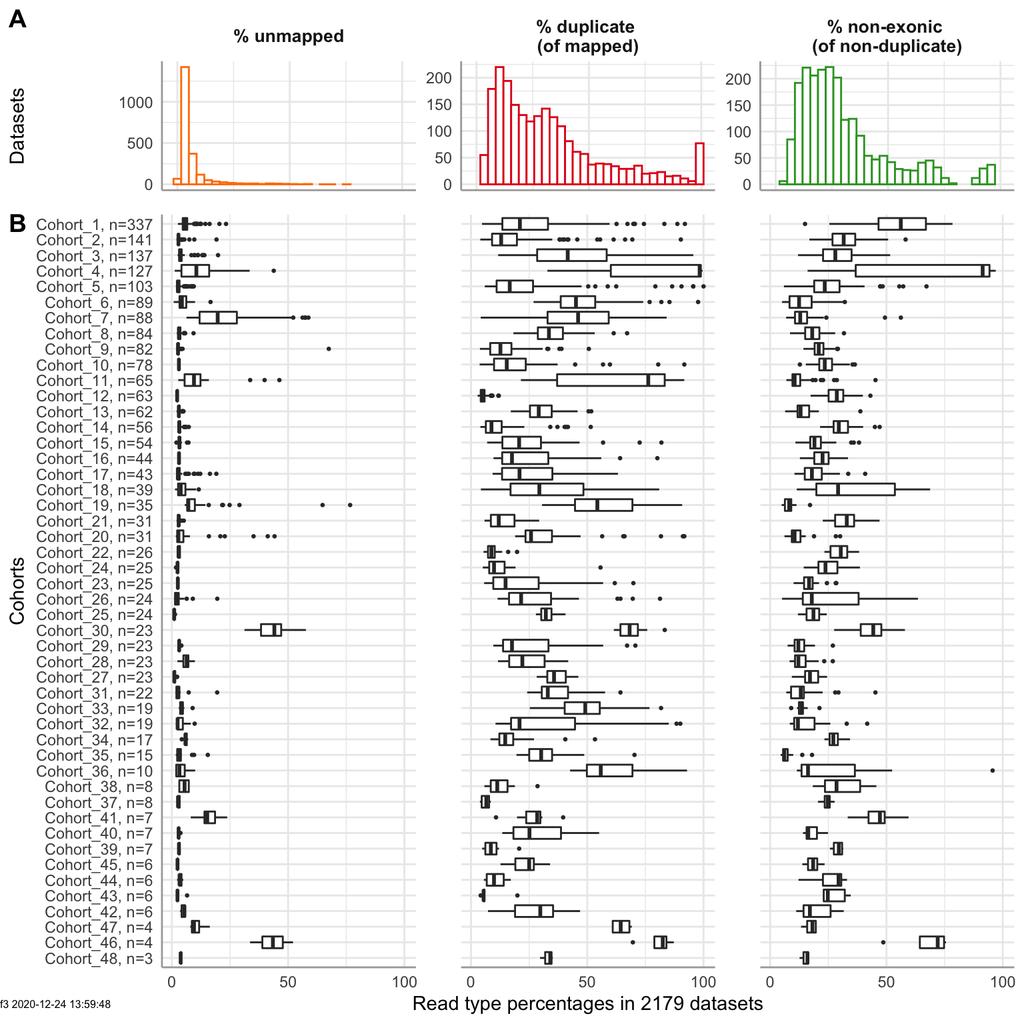

```r
#
f3a <- read_type_fractions_histogram +
            theme(strip.text.x = element_text(size = 10, face = "bold"),
                  axis.title.x=element_blank(),
                  axis.text.x=element_blank())

f3b <- read_type_fractions_per_cohort_boxplot +
            theme(strip.text.x = element_blank(),
                  strip.background = element_blank(),
                  strip.text = element_blank())

f3ab <- plot_grid(f3a,
                  f3b,
                  ncol = 1,
                  rel_heights = c(1.5, 6),
                  align = "v",
                  labels = "AUTO")
# f3c <- plot_grid(cor_plots_excluding_high_read_depth_and_low_gene_count_datasets,
#           labels = "C")


# f3 <- plot_grid(f3ab,
#                  f3c,
#                  nrow=1,
#                  rel_widths = c(4,2.3))
#
figure_name <- "f3"
f3_labeled <- f3ab +   draw_label(paste(figure_name, Sys.time()),
             x = 0, y = 0.02, hjust = 0, size = 6)


f3_labeled
```

```r
ggsave("results/Figure_3.png", f3_labeled, height=8, width=10)
ggsave("results/Figure_3.pdf", f3_labeled, height=8, width=10)
```

# Plot sequence length against pct duplicates

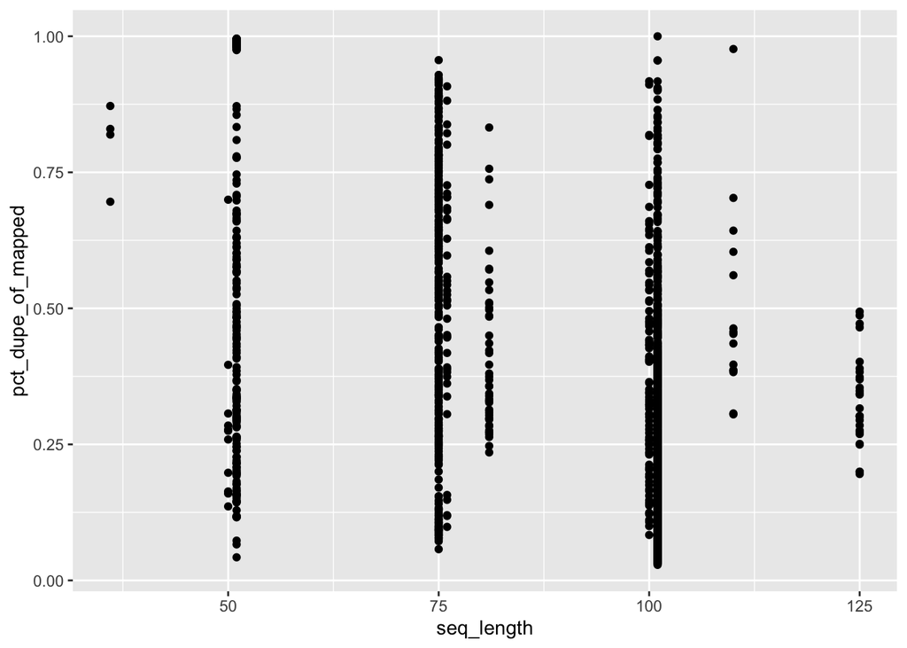

```r
ggplot(read_counts_with_read_type_fractions) +
  geom_point(aes(x=seq_length, y=pct_dupe_of_mapped))
```

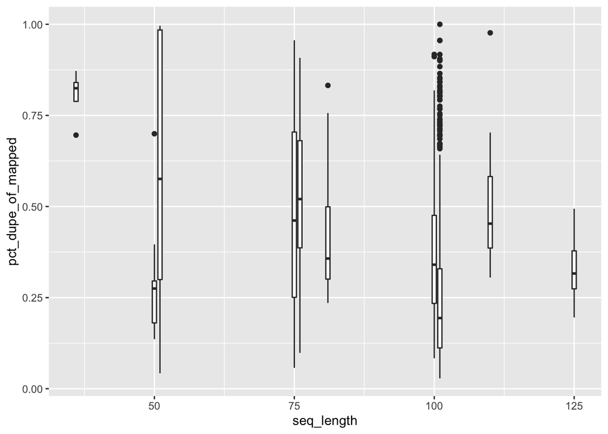

```r
ggplot(read_counts_with_read_type_fractions) +
  geom_boxplot(aes(x=seq_length, y=pct_dupe_of_mapped, group = seq_length))
```

# Generate bibtex formatted citations for packages

```r
used_pkgs <- c("base", "tidyverse", "janitor", "knitr", "cowplot", "RColorBrewer", "pander", "kableExtra", "snakecase", "corrr")
write_bib(used_pkgs)
```

```
## @Manual{R-base,
##   title = {R: A Language and Environment for Statistical Computing},
##   author = {{R Core Team}},
##   organization = {R Foundation for Statistical Computing},
##   address = {Vienna, Austria},
##   year = {2019},
##   url = {https://www.R-project.org/},
## }
## @Manual{R-corrr,
##   title = {corrr: Correlations in R},
##   author = {Max Kuhn and Simon Jackson and Jorge Cimentada},
##   year = {2020},
##   note = {R package version 0.4.3},
##   url = {https://CRAN.R-project.org/package=corrr},
## }
## @Manual{R-cowplot,
##   title = {cowplot: Streamlined Plot Theme and Plot Annotations for 'ggplot2'},
##   author = {Claus O. Wilke},
##   year = {2019},
##   note = {R package version 1.0.0},
##   url = {https://CRAN.R-project.org/package=cowplot},
## }
## @Manual{R-janitor,
##   title = {janitor: Simple Tools for Examining and Cleaning Dirty Data},
##   author = {Sam Firke},
##   year = {2019},
##   note = {R package version 1.2.0},
##   url = {https://CRAN.R-project.org/package=janitor},
## }
## @Manual{R-kableExtra,
##   title = {kableExtra: Construct Complex Table with 'kable' and Pipe Syntax},
##   author = {Hao Zhu},
##   year = {2020},
##   note = {R package version 1.3.1},
##   url = {https://CRAN.R-project.org/package=kableExtra},
## }
## @Manual{R-knitr,
##   title = {knitr: A General-Purpose Package for Dynamic Report Generation in R},
##   author = {Yihui Xie},
##   year = {2019},
```

[output cut: 16 more lines]

```
## }
## @Manual{R-snakecase,
##   title = {snakecase: Convert Strings into any Case},
##   author = {Malte Grosser},
##   year = {2019},
##   note = {R package version 0.11.0},
##   url = {https://CRAN.R-project.org/package=snakecase},
## }
## @Manual{R-tidyverse,
##   title = {tidyverse: Easily Install and Load the 'Tidyverse'},
##   author = {Hadley Wickham},
##   year = {2019},
##   note = {R package version 1.3.0},
##   url = {https://CRAN.R-project.org/package=tidyverse},
## }
```

## Does the depth of sequencing correlate to the number of duplicates?

```r
v1 <- read_counts_with_read_type_fractions$Total_reads
v2 <- read_counts_with_read_type_fractions$pct_dupe_of_mapped
#
# # cor_tot_reads_and_dupes <- cor(v1,
# #     v2,
# #     method = c("pearson"))
# #
# # round(cor_tot_reads_and_dupes, 2)
# # round(cor_tot_reads_and_dupes^2, 2)
# #
# # c1 <- cor(v1,
# #     v2,
# #     method = c("kendall"))
# # c1
# # c1^2
#
# c2 <- cor(v1,
#     v2,
#     method = "spearman")
# c2
# c2^2
#
# #
# # cor.test(v1, v2,
# #     alternative = c("two.sided"),
# #     method = c("pearson"))
# #
# # cor.test(v1, v2,
# #     alternative = c("two.sided"),
# #     method = c("kendall"))
#
# cor.test(v1, v2,
#     alternative = c("two.sided"),
#     method = "spearman")
#

cor.test(v1, v2,
    alternative = "greater", # "greater" corresponds to positive association,
    method = "spearman")
```

```
##
##  Spearman's rank correlation rho
##
## data:  v1 and v2
## S = 834427616, p-value < 2.2e-16
## alternative hypothesis: true rho is greater than 0
## sample estimates:
##       rho
## 0.5160859
```

```r
t.test(v1, v2,
       alternative = "greater",
       var.equal=FALSE)$p.value
```

```
## [1] 0
```

```r
#
# # test normality
# shapiro.test(v1)
# shapiro.test(v2)
#
# ggplot(read_counts_with_read_type_fractions) +
#   geom_histogram(aes(Total_reads)) +
#   theme_minimal()
#
# ggplot(read_counts_with_read_type_fractions) +
#   geom_histogram(aes(pct_dupe_of_mapped))  +
#   theme_minimal()
#
# ggpubr::ggqqplot(v1)
# ggpubr::ggqqplot(v2)
```

**R version 3.6.1 (2019-07-05)**

**Platform:** x86_64-apple-darwin15.6.0 (64-bit)

**locale:** en_US.UTF-8||en_US.UTF-8||en_US.UTF-8||C||en_US.UTF-8||en_US.UTF-8

**attached base packages:**

- stats
- graphics
- grDevices
- utils
- datasets
- methods
- base

**other attached packages:**

- corrr(v.0.4.3)
- snakecase(v.0.11.0)
- kableExtra(v.1.3.1)
- pander(v.0.6.3)
- RColorBrewer(v.1.1-2)
- cowplot(v.1.0.0)
- knitr(v.1.25)
- janitor(v.1.2.0)
- forcats(v.0.4.0)
- stringr(v.1.4.0)
- dplyr(v.1.0.2)
- purrr(v.0.3.3)
- readr(v.1.3.1)
- tidyr(v.1.0.2)
- tibble(v.3.0.4)
- ggplot2(v.3.3.2)
- tidyverse(v.1.3.0)

**loaded via a namespace (and not attached):**

- Rcpp(v.1.0.5)
- lubridate(v.1.7.4)
- utf8(v.1.1.4)
- assertthat(v.0.2.1)
- digest(v.0.6.27)
- R6(v.2.5.0)
- cellranger(v.1.1.0)
- backports(v.1.1.4)
- reprex(v.0.3.0)
- evaluate(v.0.14)
- httr(v.1.4.1)
- highr(v.0.8)
- pillar(v.1.4.7)
- rlang(v.0.4.9)
- readxl(v.1.3.1)
- rstudioapi(v.0.13)
- rmarkdown(v.1.15)
- labeling(v.0.4.2)
- webshot(v.0.5.2)
- munsell(v.0.5.0)
- broom(v.0.7.3)
- compiler(v.3.6.1)
- modelr(v.0.1.5)
- xfun(v.0.9)
- pkgconfig(v.2.0.3)
- htmltools(v.0.4.0)
- tidyselect(v.1.1.0)
- fansi(v.0.4.1)
- viridisLite(v.0.3.0)
- crayon(v.1.3.4)
- dbplyr(v.1.4.2)
- withr(v.2.3.0)
- grid(v.3.6.1)
- jsonlite(v.1.7.1)
- gtable(v.0.3.0)
- lifecycle(v.0.2.0)
- DBI(v.1.0.0)
- magrittr(v.2.0.1)
- scales(v.1.1.1)
- cli(v.2.2.0)
- stringi(v.1.4.3)
- farver(v.2.0.3)
- fs(v.1.3.1)
- xml2(v.1.2.2)
- ellipsis(v.0.3.1)
- generics(v.0.0.2)
- vctrs(v.0.3.5)
- tools(v.3.6.1)
- glue(v.1.4.2)
- hms(v.0.5.3)
- yaml(v.2.2.0)
- colorspace(v.2.0-0)
- rvest(v.0.3.6)
- haven(v.2.3.1)